# BootCamp ATLAS #2

*Author : Dominika Stępniewska*

## Podział modeli uczenia maszynowego

Modele uczenia maszynowego możemy podzielić na 3 podstawowe typy:

- nadzorowane - dane uczące przekazywane algorytmowi zawierają dołączone rozwiązania problemu (etykiety).

*Przykład:* Przewidywanie cen mieszkań lub klasyfikowanie spamu.

- nienadzorowane - dane uczące są nieoznakowane.

*Przykład:* Określenie grup podobnych użytkowników odwiedzających Twój blog za pomocą analizy skupień.

- uczenie przez wzmacnianie - system uczący (agent) obserwuje środowisko, dobiera i wykonuje czynności, a także odbiera nagrody lub kary. Musi nauczyć się najlepszej strategii (polityki), aby uzyskiwać jak najwyższą nagrodę.

*Przykład*: Program AlphaGo firmy DeepMind, który w 2017 roku pokonał ówczesnego mistrza w grę Go

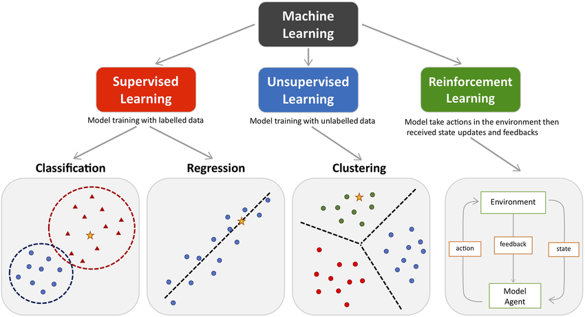

Regresję i klasyfikację zaliczamy do kategorii uczenia nadzorowanego.

**Dla dociekliwych:** Wśród kategorii uczenia maszynowego możemy wyróżnić także uczenie półnadzorowane i uczenie samonadzorowane. Więcej: https://medium.com/imagescv/learning-supervised-unsupervised-self-supervised-semi-supervised-aa0a5d6d7010.

## Regresja i klasyfikacja - porównanie

| Regresja | Klasyfikacja |
| --- | --- |
| przewidywanie wartości numerycznej lub ciągłej | przewidywanie wartości kategorycznych (klas) |
| problemy takie jak przewidywanie cen mieszkań, przewidywanie ilości opadów | problemy takie jak klasyfikacja spamu, przewidywanie chorób |
| przykładowe miary dopasowania modelu: $R^2, RMSE, MAE$ | przykładowe miary dopasowania modelu: dokładność, precyzja, czułość, krzywa ROC |
| przykładowe algorytmy: regresja liniowa, regresja wielomianowa | przykładowe algorytmy: regresja logistyczna, naiwny klasyfikator bayesowski |

Algorytmy takie jak drzewo decyzyjne, las losowy, k-najbliższych sąsiadów czy maszyna wektorów nośnych (SVM) mogą być używane zarówno do zagadnień regresyjnych, jak i klasyfikacyjnych.

### Jak dzielimy modele klasyfikacyjne?

Modele klasyfikacyjne dzielimy na modele z binarną zmienną wynikową (np. czy pacjent jest chory na COVID) oraz ze zmienną wynikową wielostanową (np. ocena z analizy matematycznej na koniec semestru). W zależności od rodzaju modelu, stosujemy różne miary dopasowania.

## Modele w praktyce

### Regresja

#### Regresja liniowa

Jednym z modeli służącym do zagadnień regresyjnych jest model regresji liniowej. Regresja liniowa wyraża się wzorem

$$y_i = \beta_0 + \beta_1x_{i1}. + ... + \beta_px_{ip} + \varepsilon_i$$

$y_i$ - zmienna zależna

$\beta_0$ - wyraz wolny modelu

$\beta_1, ..., \beta_p$ - współczynniki regresji

$x_i1, ..., x_ip$ - zmienne niezależne dla $i$-tej obserwacji

$\varepsilon_i$ - składnik losowy (błąd)

Zbudujmy model regresji liniowej, w którym będziemy przewidywać długość głowy oposa na podstawie jego pozostałych wymiarów. Skorzystamy ze zbioru danych https://www.kaggle.com/datasets/abrambeyer/openintro-possum.

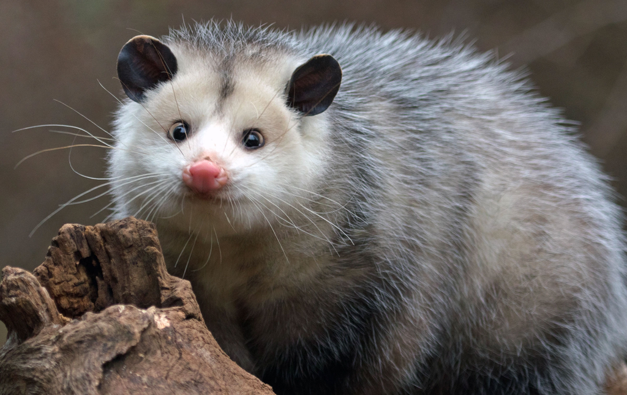

```python
# Potrzebne biblioteki
import pandas as pd
import numpy as np
from sklearn.model_selection import train_test_split
from sklearn.linear_model import LinearRegression
from sklearn.metrics import r2_score
from sklearn.metrics import mean_squared_error
from sklearn.metrics import mean_absolute_error
from xgboost import XGBRegressor
import matplotlib.pyplot as plt
import seaborn as sns
from sklearn.tree import DecisionTreeClassifier
from sklearn.ensemble import RandomForestClassifier
from sklearn.svm import SVC
from sklearn.naive_bayes import GaussianNB
from xgboost import XGBClassifier
from sklearn.metrics import accuracy_score
from sklearn.metrics import recall_score
from imblearn.metrics import specificity_score
from sklearn.metrics import confusion_matrix
from sklearn.metrics import ConfusionMatrixDisplay
```

```python
# Wgrywamy dane
data = pd.read_csv('possum.csv')
data.head()
```

|  | case | site | Pop | sex | age | hdlngth | skullw | totlngth | taill | footlgth | earconch | eye | chest | belly |
| --- | --- | --- | --- | --- | --- | --- | --- | --- | --- | --- | --- | --- | --- | --- |
| 0 | 1 | 1 | Vic | m | 8.0 | 94.1 | 60.4 | 89.0 | 36.0 | 74.5 | 54.5 | 15.2 | 28.0 | 36.0 |
| 1 | 2 | 1 | Vic | f | 6.0 | 92.5 | 57.6 | 91.5 | 36.5 | 72.5 | 51.2 | 16.0 | 28.5 | 33.0 |
| 2 | 3 | 1 | Vic | f | 6.0 | 94.0 | 60.0 | 95.5 | 39.0 | 75.4 | 51.9 | 15.5 | 30.0 | 34.0 |
| 3 | 4 | 1 | Vic | f | 6.0 | 93.2 | 57.1 | 92.0 | 38.0 | 76.1 | 52.2 | 15.2 | 28.0 | 34.0 |
| 4 | 5 | 1 | Vic | f | 2.0 | 91.5 | 56.3 | 85.5 | 36.0 | 71.0 | 53.2 | 15.1 | 28.5 | 33.0 |

```python
# Usuwamy braki danych
data = data.dropna()

# Usuwamy zmienną 'case' - identyfikator oposa
data = data.drop('case', axis=1)

# Usuwamy zmienne, które nie są wymiarami oposa
data = data.drop(['site','Pop','sex','age'], axis=1)
```

```python
# X - zmienne niezależne (predyktory), y - zmienna zależna (wynikowa)
X = data.drop('hdlngth', axis=1)
y = data['hdlngth']

# Dzielimy zbiór na uczący i testowy
X_train, X_test, y_train, y_test = train_test_split(X, y, test_size=0.2, random_state=42)
```

```python
# Tworzymy model regresji liniowej
lr_model = LinearRegression()

# Trenujemy model na danych treningowych
lr_model.fit(X_train, y_train)

# Przewidujemy wartość zmiennej zależnej dla danych testowych
y_pred_lr = lr_model.predict(X_test)
```

#### Miary jakości dopasowania modelu

- Współczynnik determinacji $R^2$

Informuje o tym, jak duża część zmienności zmiennej zależnej jest wyjaśniana przez zmienne niezależne. Przyjmuje wartości w przedziale $[0,1]$, im większa wartość, tym model jest lepiej dopasowany.

$$R^2 = 1 -\frac{\sum_{i}{(y_i-\hat{y_i})^2}}{\sum_{i}{(y_i-\bar{y})^2}}$$

$y_i$ – $i$-ta wartość obserwowana

$\hat{y_i}$ – $i$-ta wartość przewidywana na podstawie modelu

$\bar{y}$ – średnia zmiennej wynikowej

```python
r2_score(y_test, y_pred_lr)
```

```
0.7250233423383643
```

- Pierwiastek błędu średniokwadratowego - $RMSE$

Określa, o ile przeciętnie wartości empiryczne zmiennej objaśnianej odchylają się od wartości teorytycznych tej zmiennej, obliczonej na podstawie zbudowanego modelu. Im mniejsza wartość $RMSE$, tym model jest lepiej dopasowany.

$$RMSE = \sqrt{\frac{\sum_{i=1}^{n}{(y_i-\hat{y}_i)^2}}{n}}$$

$n$ - liczebność zbioru

```python
np.sqrt(mean_squared_error(y_test, y_pred_lr))
```

```
1.8981845455402748
```

- Średni błąd bezwzględny - $MAE$

Informuje, o ile średnio rzeczywiste wartości zmiennej objaśnianej różnią się, co do bezwzględnej wartości, od prognoz. Im mniejsza wartość $MAE$, tym model jest lepiej dopasowany.

$$MAE = \frac{\sum_{i=1}^{n}{|y_i-\hat{y_i}|}}{n}$$

```python
mean_absolute_error(y_test, y_pred_lr)
```

```
1.4444271527602979
```

#### XGBoost

Extreme Gradient Boosting (XGBoost) to algorytm oparty na wzmacnianiu gradientowym. Może być stosowany zarówno do zagadnień regresji jak i klasyfikacji.

```python
# Tworzymy model XGBoost
xgbr_model = XGBRegressor()

xgbr_model.fit(X_train, y_train)

y_pred_xgbr = xgbr_model.predict(X_test)
```

Miary dopasowania modelu

```python
r2_score(y_test, y_pred_xgbr)
```

```
0.6354436152234071
```

```python
np.sqrt(mean_squared_error(y_test, y_pred_xgbr))
```

```
2.1856110271358746
```

```python
mean_absolute_error(y_test, y_pred_xgbr)
```

```
1.6936121622721363
```

Porównajmy otrzymane modele

|  | Regresja liniowa | XGBoost |
| --- | --- | --- |
| $R^2$ | 0.73 | 0.64 |
| $RMSE$ | 1.90 | 2.19 |
| $MAE$ | 1.44 | 1.69 |

Na podstawie powyższych metryk, który model jest lepiej dopasowany do danych?

Stworzymy wykresy wartości dopasowanych i obserwowanych obu modeli.

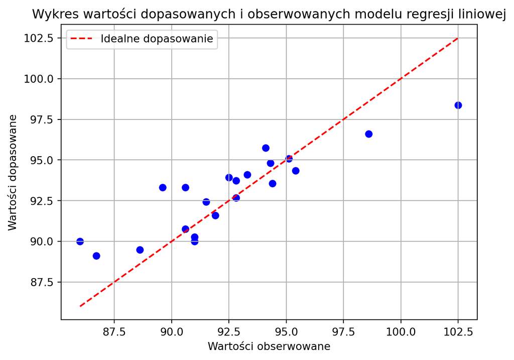

```python
# Wykres punktowy
plt.scatter(y_test, y_pred_lr, color='blue')

# Prosta na wykresie
plt.plot([min(y_test), max(y_test)], [min(y_test), max(y_test)], color='red', linestyle='--', label='Idealne dopasowanie')

# Etykiety osi x i y, tytuł, legenda, siatka
plt.xlabel('Wartości obserwowane')
plt.ylabel('Wartości dopasowane')
plt.title('Wykres wartości dopasowanych i obserwowanych modelu regresji liniowej')
plt.legend()
plt.grid()

# Wyświetlenie wykresu
plt.show()
```

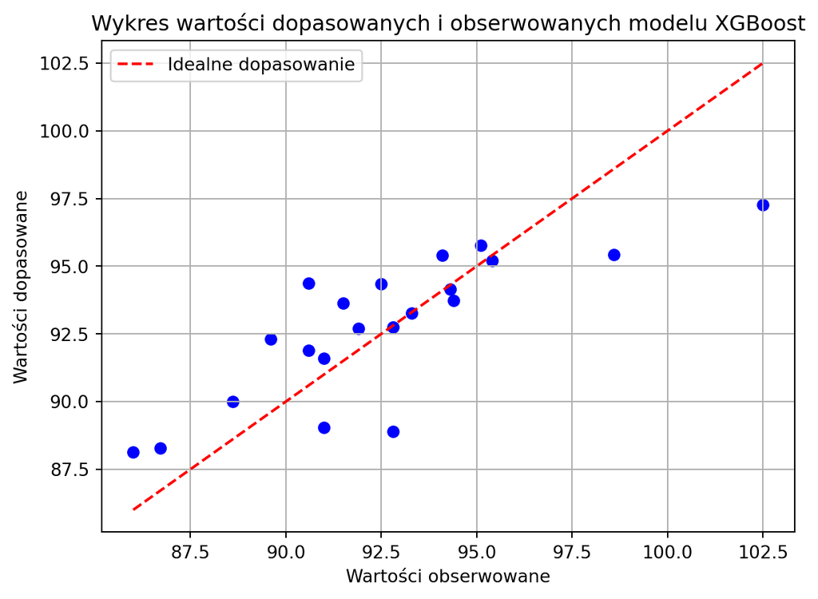

```python
plt.scatter(y_test, y_pred_xgbr, color='blue')
plt.plot([min(y_test), max(y_test)], [min(y_test), max(y_test)], color='red', linestyle='--', label='Idealne dopasowanie')
plt.xlabel('Wartości obserwowane')
plt.ylabel('Wartości dopasowane')
plt.title('Wykres wartości dopasowanych i obserwowanych modelu XGBoost')
plt.legend()
plt.grid()
plt.show()
```

### Klasyfikacja

Zajmiemy się problemem klasyfikacji. Naszym celem jest zbudowanie modelu, który pozwoli nam przewidzieć czy dana osoba woli góry czy morze, na podstawie jej różnych cech, m.in. wieku, wykształcenia, częstotliwości podróżowania czy ulubionej pory roku. Jest to zagadnienie klasyfiakcji binarnej, ponieważ zmienna wynikowa ma 2 wartości - góry i morze. Skorzystamy ze zbioru https://www.kaggle.com/datasets/jahnavipaliwal/mountains-vs-beaches-preference.

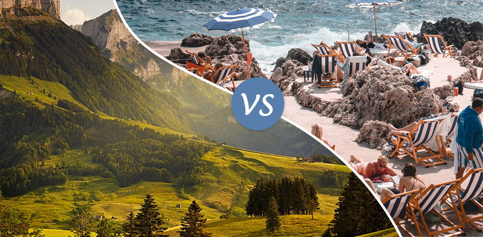

#### Drzewo decyzyjne

Drzewo decyzyjne to hierarchiczna struktura składająca się z korzenia (*root*), węzłów (*nodes*) i liści (*leaves*). Korzeń to początkowy węzeł drzewa, z którego poprzez podziały powstają kolejne węzły potomne. Aby zbudować drzewo, algorytm przeszukuje wszystkie możliwe testy i znajduje ten, który zawiera najwięcej informacji o zmiennej docelowej. Drzewo dąży do takiego podziału, by kolejne węzły były jak najbardziej jednorodne ze względu na zmienną wynikową.

```python
data2 = pd.read_csv('mountains_vs_beaches_preferences.csv')
data2.head()
```

|  | Age | Gender | Income | Education_Level | Travel_Frequency | Preferred_Activities | Vacation_Budget | Location | Proximity_to_Mountains | Proximity_to_Beaches | Favorite_Season | Pets | Environmental_Concerns | Preference |
| --- | --- | --- | --- | --- | --- | --- | --- | --- | --- | --- | --- | --- | --- | --- |
| 0 | 56 | male | 71477 | bachelor | 9 | skiing | 2477 | urban | 175 | 267 | summer | 0 | 1 | 1 |
| 1 | 69 | male | 88740 | master | 1 | swimming | 4777 | suburban | 228 | 190 | fall | 0 | 1 | 0 |
| 2 | 46 | female | 46562 | master | 0 | skiing | 1469 | urban | 71 | 280 | winter | 0 | 0 | 1 |
| 3 | 32 | non-binary | 99044 | high school | 6 | hiking | 1482 | rural | 31 | 255 | summer | 1 | 0 | 1 |
| 4 | 60 | female | 106583 | high school | 5 | sunbathing | 516 | suburban | 23 | 151 | winter | 1 | 1 | 0 |

```python
# Sprawdzamy, czy zbiór danych zawiera braki
data2.isnull().sum()
```

```
Age                       0
Gender                    0
Income                    0
Education_Level           0
Travel_Frequency          0
Preferred_Activities      0
Vacation_Budget           0
Location                  0
Proximity_to_Mountains    0
Proximity_to_Beaches      0
Favorite_Season           0
Pets                      0
Environmental_Concerns    0
Preference                0
dtype: int64
```

```python
# Sprawdzamy typy danych
data2.info()
```

```
<class 'pandas.core.frame.DataFrame'>
RangeIndex: 52444 entries, 0 to 52443
Data columns (total 14 columns):
 #   Column                  Non-Null Count  Dtype
---  ------                  --------------  -----
 0   Age                     52444 non-null  int64
 1   Gender                  52444 non-null  object
 2   Income                  52444 non-null  int64
 3   Education_Level         52444 non-null  object
 4   Travel_Frequency        52444 non-null  int64
 5   Preferred_Activities    52444 non-null  object
 6   Vacation_Budget         52444 non-null  int64
 7   Location                52444 non-null  object
 8   Proximity_to_Mountains  52444 non-null  int64
 9   Proximity_to_Beaches    52444 non-null  int64
 10  Favorite_Season         52444 non-null  object
 11  Pets                    52444 non-null  int64
 12  Environmental_Concerns  52444 non-null  int64
 13  Preference              52444 non-null  int64
dtypes: int64(9), object(5)
memory usage: 5.6+ MB
```

```python
X = data2.drop('Preference', axis=1)
y = data2['Preference']

X_train, X_test, y_train, y_test = train_test_split(X, y, test_size=0.2, random_state=42)
```

```python
# Tworzymy model drzewa decyzyjnego
dt_model = DecisionTreeClassifier()
```

```python
# dt_model.fit(X_train, y_train)
```

Przy próbie wytrenowania modelu na danych treningowych pojawia się błąd:

[figure not shown]

Jak widać powyżej (sprawdzenie typów danych), zmienne `Gender`, `Education_Level`, `Preferred_Activities`, `Location` oraz `Favorite_Season` są typu object. Algorytm drzewa decyzyjnego obsługuje zarówno zmienne numeryczne jak i kategoryczne, jednak zmienne kategoryczne powinny zostać zakodowane do numerycznej reprezentacji. W tym celu zastosujemy kodowanie one-hot encoding.

#### One-hot encoding

Sprawdźmy jak działa kodowanie na przykładzie zmiennych kategorycznych `Location` i `Favorite_Season`. Przed kodowaniem, każda z nich jest reprezentowana przez jedną zmienną, odpowiednio z 3 (`urban`, `suburban`, `rural`) i 4 (`spring`, `summer`, `fall`, `winter`) poziomami.

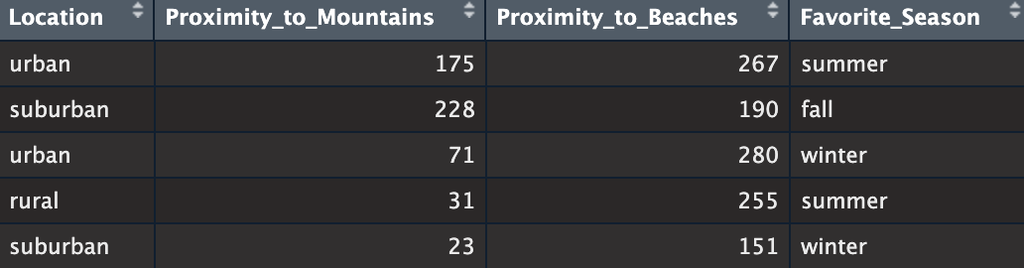

```python
# Kodowanie zmiennych kategorycznych
one_hot_data = pd.get_dummies(data2, columns = ['Gender','Education_Level','Preferred_Activities','Location','Favorite_Season'])
```

Zmienne po kodowaniu:

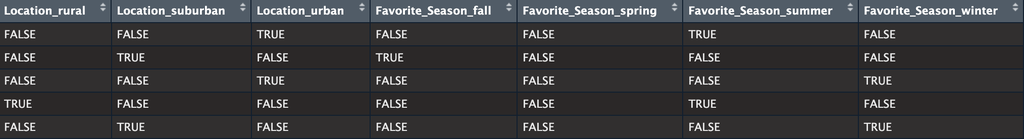

W wyniku kodowania one-hot, każda cecha jest reprezentowana przez liczbę zmiennych binarnych równą liczbie kategorii.

Po takim przekształceniu możemy kontynuować tworzenie modeli.

```python
X = one_hot_data.drop('Preference', axis=1)
y = one_hot_data['Preference']

X_train, X_test, y_train, y_test = train_test_split(X, y, test_size=0.2, random_state=42)
```

```python
dt_model = DecisionTreeClassifier()

dt_model.fit(X_train, y_train)

y_pred_dt = dt_model.predict(X_test)
```

#### Las losowy

Las losowy to zestaw drzew decyzyjnych, w którym każde różni się nieco od pozostałych. Każde drzewo może stosunkowo dobrze prognozować, ale prawdopodobnie będzie nadmiernie dopasowywać się do części danych. To nadmierne dopasowanie można zmniejszyć budując wiele drzew (z których wszystkie działają dobrze i są na różne sposoby nadmiernie dopasowane) i uśredniając ich wyniki.

```python
rf_model = RandomForestClassifier()

rf_model.fit(X_train, y_train)

y_pred_rf = rf_model.predict(X_test)
```

#### Maszyna wektorów nośnych SVM

Istotą metody SVM jest znalezienie wektorów nośnych, definiujących hiperpowierzchnie optymalnie separujące obiekty w homogeniczne grupy.

```python
svm_model = SVC()

svm_model.fit(X_train, y_train)

y_pred_svm = svm_model.predict(X_test)
```

#### Naiwny klasyfikator Bayesa

Naiwny klasyfikator Bayesa to technika klasyfikacji, która opiera się na podejściu probabilistycznym i rozkładzie gaussowskim. Zakłada, że każdy predyktor ma niezależną zdolność przewidywania zmiennej wyjściowej.

```python
nb_model = GaussianNB()

nb_model.fit(X_train, y_train)

y_pred_nb = nb_model.predict(X_test)
```

#### XGBoost

```python
xgbc_model = XGBClassifier()

xgbc_model.fit(X_train, y_train)

y_pred_xgbc = xgbc_model.predict(X_test)
```

#### Miary jakości dopasowania modelu

Do oceny jakości dopasowania modelu użyjemy następujących miar:

- Dokładność (Accuracy) - informuje o odsetku poprawnie zaklasyfikowanych obserwacji.

$$ACC = \frac{TP+TN}{P+N}$$

$TP$ - liczba poprawnie zaklasyfikowanych pozytywnych przypadków

$TN$ - liczba poprawnie zaklasyfikowanych negatywnych przypadków

$P$ - liczba rzeczywistych pozytywnych przypadków

$N$ - liczba rzeczywistych negatywnych przypadków

Dokładność możemy obliczyć za pomocą funkcji `accuracy_score(y_true, y_pred)`, gdzie `y_true` to rzeczywiste wartości, a `y_pred` to wartości przewidziane przez model.

- Czułość (Recall) - stosunek liczby poprawnie zaklasyfikowanych pozytywnych przypadków do liczby rzeczywistych pozytywnych przypadków

$$TPR = \frac{TP}{P}$$

Obliczamy za pomocą funkcji `recall_score()`

- Swoistość (Specificity) - stosunek liczby poprawnie zaklasyfikowanych negatywnych przypadków do liczby rzeczywistych negatywnych przypadków

$$TNR = \frac{TN}{N}$$

Obliczamy za pomocą funkcji `specificity_score().`

Napiszemy teraz funkcję, dzięki której obliczymy powyższe miary dla wszystkich pięciu modeli.

```python
# Funkcja, która jako argumenty przyjmuje rzeczywiste wartości zbioru testowego oraz wartości przewidziane przez model

def cl_metrics(y_true, y_pred):
  accuracy = round(accuracy_score(y_true, y_pred),2)
  recall = round(recall_score(y_true, y_pred),2)
  specificity = round(specificity_score(y_true, y_pred),2)
  return accuracy, recall, specificity

# round(x, 2) - zaokrąglamy x do 2 miejsc po przecinku
```

```python
# Tworzymy słownik, w którym kluczem jest nazwa modelu, a wartością - wartości przewidziane przez model
cl_models = {'DT': y_pred_dt,
             'RF': y_pred_rf,
             'SVM': y_pred_svm,
             'NB': y_pred_nb,
             'XGB': y_pred_xgbc}
```

```python
# Tworzymy pustą listę, w której zapiszemy wyniki
results = []

# Za pomocą pętli, obliczamy metryki dla wszystkich modeli (elementów słownika) przy użyciu wcześniej zdefiniowanej funkcji, a następnie dopisujemy wyniki do listy

for model, y_pred in cl_models.items():
  accuracy, recall, specificity = cl_metrics(y_test, y_pred)
  results.append({
    'Model': model,
    'Accuracy': accuracy,
    'Recall': recall,
    'Specificity': specificity
  })
```

```python
# Wyświetlamy listę jako ramkę danych
pd.DataFrame(results)
```

|  | Model | Accuracy | Recall | Specificity |
| --- | --- | --- | --- | --- |
| 0 | DT | 0.99 | 0.99 | 1.00 |
| 1 | RF | 0.99 | 0.98 | 1.00 |
| 2 | SVM | 0.75 | 0.00 | 1.00 |
| 3 | NB | 0.83 | 0.48 | 0.94 |
| 4 | XGB | 1.00 | 0.99 | 1.00 |

Modelem najlepiej dopasowanym do danych jest XGBoost, a najgorzej - maszyna wektorów nośnych SVM. Stworzymy funkcję, za pomocą której wyświetlimy macierz pomyłek dla każdego modelu.

```python
# Funkcja jako argumenty przyjmuje wartości rzeczywiste, wartości przewidywane przez model oraz tytuł

def plot_confmat(y_test, y_pred, title):

  # Tworzymy tablicę pomyłek
  cm = confusion_matrix(y_test, y_pred)

  # Tworzymy macierz i ją wyświetlamy
  cm_disp = ConfusionMatrixDisplay(confusion_matrix=cm)
  cm_disp.plot(cmap = plt.cm.Blues)
  plt.title(title)
  plt.show()
```

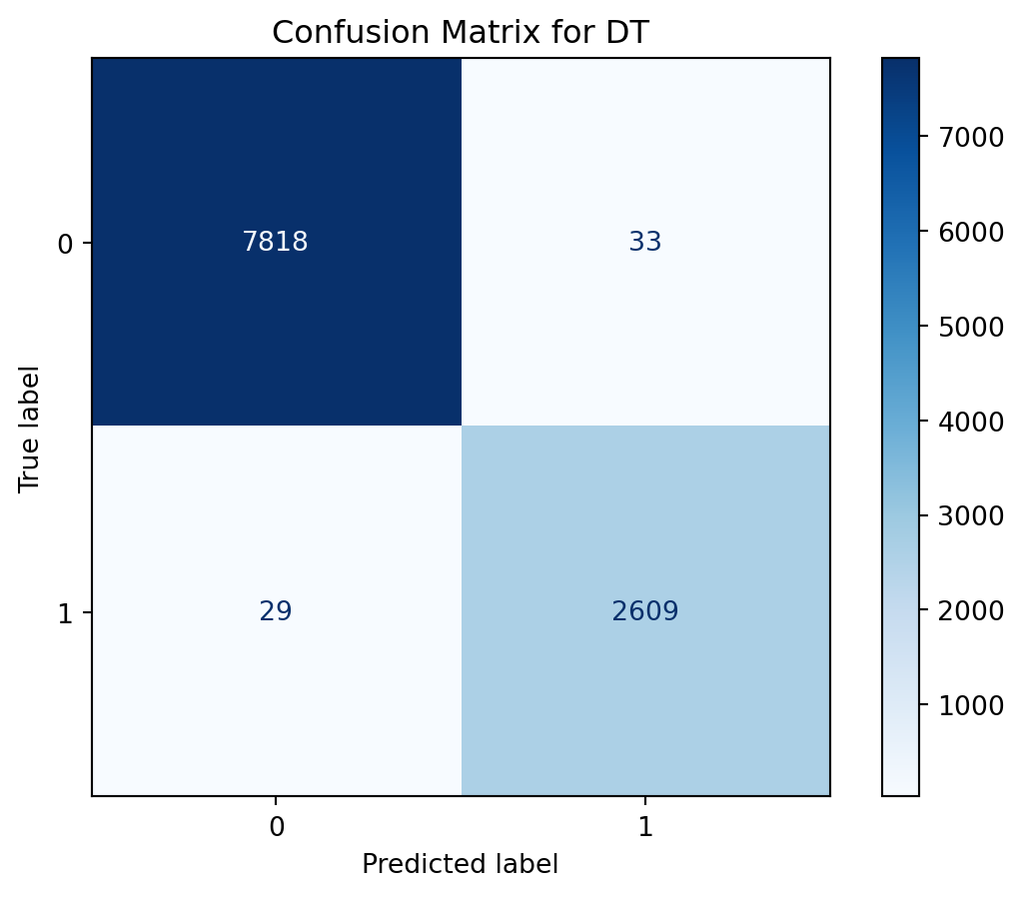

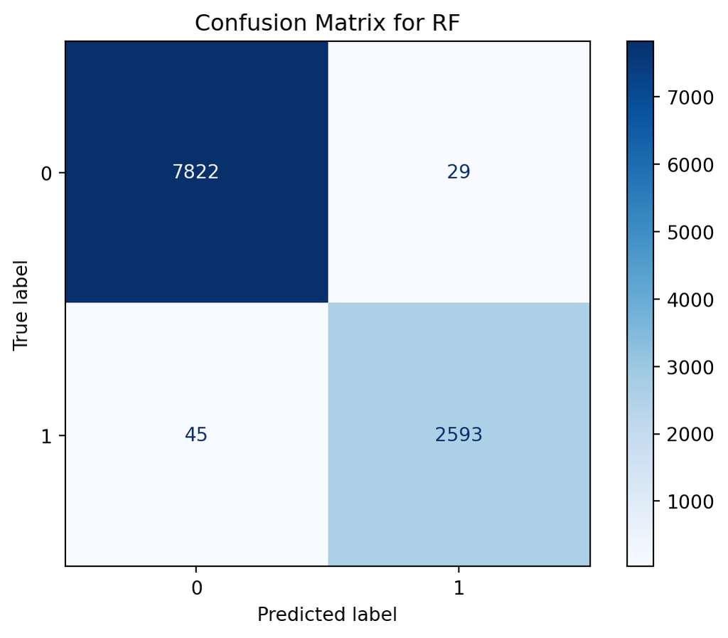

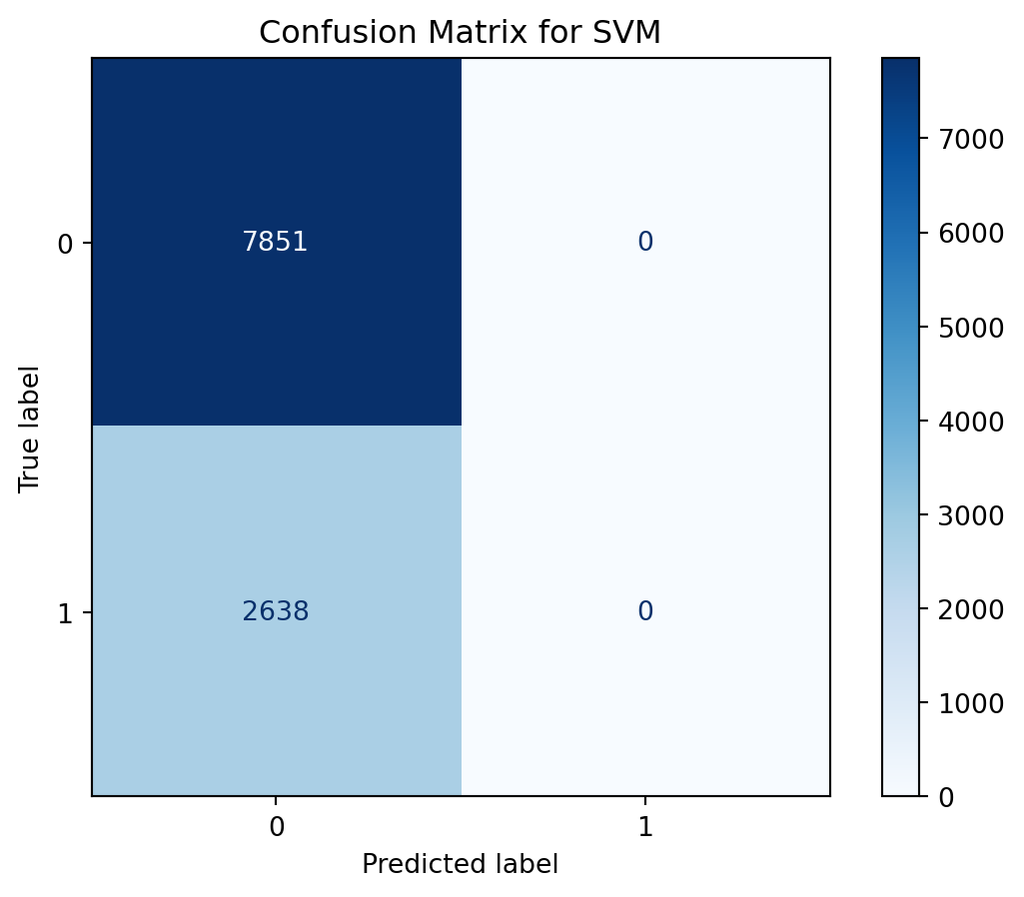

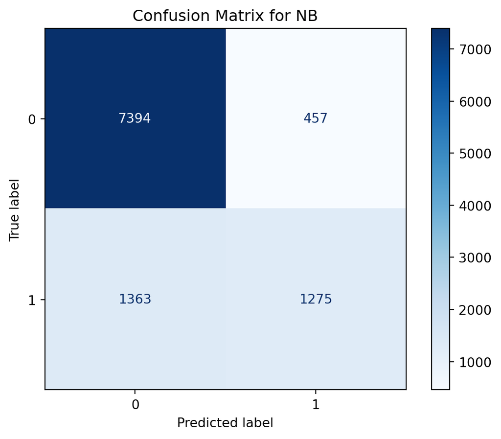

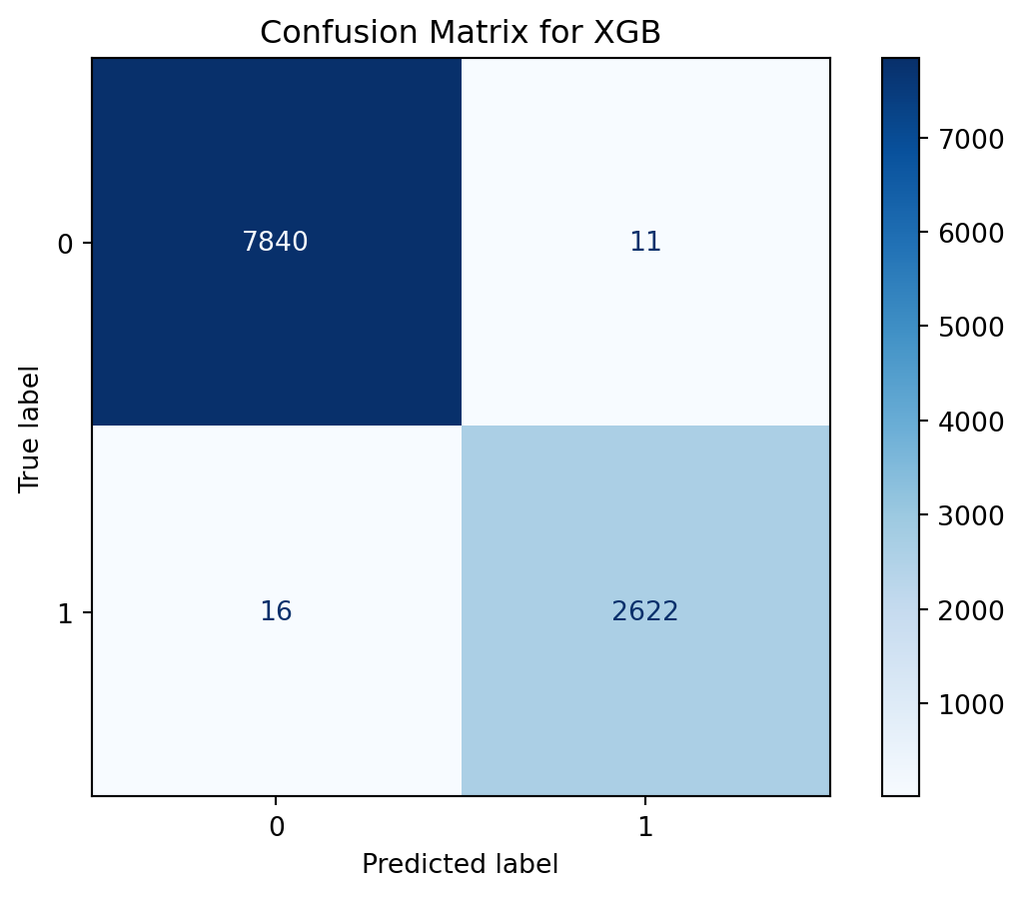

```python
# Za pomocą pętli wywołujemy funkcję dla każdego z pięciu modeli
for model, y_pred in cl_models.items():
  plot_confmat(y_test, y_pred, title=f'Confusion Matrix for {model}')
```

*Interpretacja na przykładzie macierzy pomyłek modelu XGBoost (XGB)*: Model poprawnie przewidział 7840 wartości negatywnych jako negatywne i 2622 wartości pozytywne jako pozytywne. W 16 przypadkach model przewidział wartość negatywną, a rzeczywista wartość była pozytywna. W 11 przypadkach model przewidział wartość pozytywną, a rzeczywista wartość była negatywna.

## Źródła

- “Machine learning, Python i data science. Wprowadzenie” Andreas Müller, Sarah Guido
- https://dax44-datamining.netlify.app/
- https://majerek.quarto.pub/metody-walidacji-modeli-statystycznych/